# Crash Report

# Project 1

## Introduction:

This project studies common patterns regardiing crashes in Montgomery County regarding weather conditions, car sizes, and damage to the humans and vehicles involved.

### Data Cleaning:

For this data, the causes of the empty rows was not always clear, however it was clear that they could not be simply removed. Instead, they were integrated into pre-existing categories based on what was the most similar. In most cases, this meant replacing NA value with “UNKNOWN”.The columns in which this could not be done due to either the collumn not having an “UNKNOWN” category, or the “UNKNOWN” category having additional meaning were not used.

```r
dat = read.csv("https://raw.githubusercontent.com/IsraelAndrade22/MontgomeryCountyCrashData/master/Crash_Reporting_-_Drivers_Data.csv")
#data cleaning
dat$Driver.Substance.Abuse[is.na(dat$Driver.Substance.Abuse)] = "UNKNOWN"
dat$Driver.Substance.Abuse[dat$Driver.Substance.Abuse == "N/A"] = "UNKNOWN"
dat$Vehicle.Movement[dat$Vehicle.Movement == "N/A"] = "UNKNOWN"
dat$Vehicle.Body.Type[dat$Vehicle.Body.Type == "N/A"] = "UNKNOWN"
dat$Vehicle.Damage.Extent[dat$Vehicle.Damage.Extent == "N/A"] = "UNKNOWN"
dat$Light[dat$Light == "N/A"] = "UNKNOWN"
dat$Surface.Condition[dat$Surface.Condition == "N/A"] = "UNKNOWN"
dat$Weather[dat$Weather == "N/A"] = "UNKNOWN"
dat$Collision.Type[dat$Collision.Type == "N/A"] = "UNKNOWN"

dat$Driver.Substance.Abuse = factor(dat$Driver.Substance.Abuse)
dat$Vehicle.Movement = factor(dat$Vehicle.Movement)
dat$Vehicle.Body.Type = factor(dat$Vehicle.Body.Type)
dat$Vehicle.Damage.Extent = factor(dat$Vehicle.Damage.Extent)
dat$Light = factor(dat$Light)
dat$Surface.Condition = factor(dat$Surface.Condition)
dat$Weather = factor(dat$Weather)
dat$Collision.Type = factor(dat$Collision.Type)
```

## Data:

The data comes from the datMontgomery website. The dataset consist of information about drivers who have been involved in traffic collisions. The data is obtained via the Automated Crash Reporting System and updated weekly.

## Initial data exploration:

Each row of the data is a information about a driver and details about the collisions they were involved in. The number of rows in this data set consist 65841 and 32 columns. The majority of the data is of type string with a few exceptions being crash time, latitude, longitude, and location all being numeric. In addition, most attributes/columns have factors of 3 or greater besides Latitude and Longitude.

```r
names(dat)
```

```
##  [1] "Report.Number"                "Local.Case.Number"
##  [3] "Agency.Name"                  "ACRS.Report.Type"
##  [5] "Crash.Date.Time"              "Route.Type"
##  [7] "Road.Name"                    "Cross.Street.Type"
##  [9] "Cross.Street.Name"            "Off.Road.Description"
## [11] "Municipality"                 "Related.Non.Motorist"
## [13] "Collision.Type"               "Weather"
## [15] "Surface.Condition"            "Light"
## [17] "Traffic.Control"              "Driver.Substance.Abuse"
## [19] "Non.Motorist.Substance.Abuse" "Person.ID"
## [21] "Driver.At.Fault"              "Injury.Severity"
## [23] "Circumstance"                 "Driver.Distracted.By"
## [25] "Drivers.License.State"        "Vehicle.ID"
## [27] "Vehicle.Damage.Extent"        "Vehicle.Body.Type"
## [29] "Vehicle.Movement"             "Latitude"
## [31] "Longitude"                    "Location"
```

## Data exploration and visualization:

The graphs below have a description and result explaining the graph and also its findings

## Frequency of the weather conditions of vechicle crashes

### Description:

In this graph we wanted to view the number of crashes based on the weather condition when the crash happened

### Results:

The weather conditions involved with the most crashed ranged from Clear, Raining, Cloudy, followed by other. The result was a bit surprising as we did not expect as many crashes to occur when the weather condition was clear, but it’s understandable as the majority of the time the weather conditions are clear.

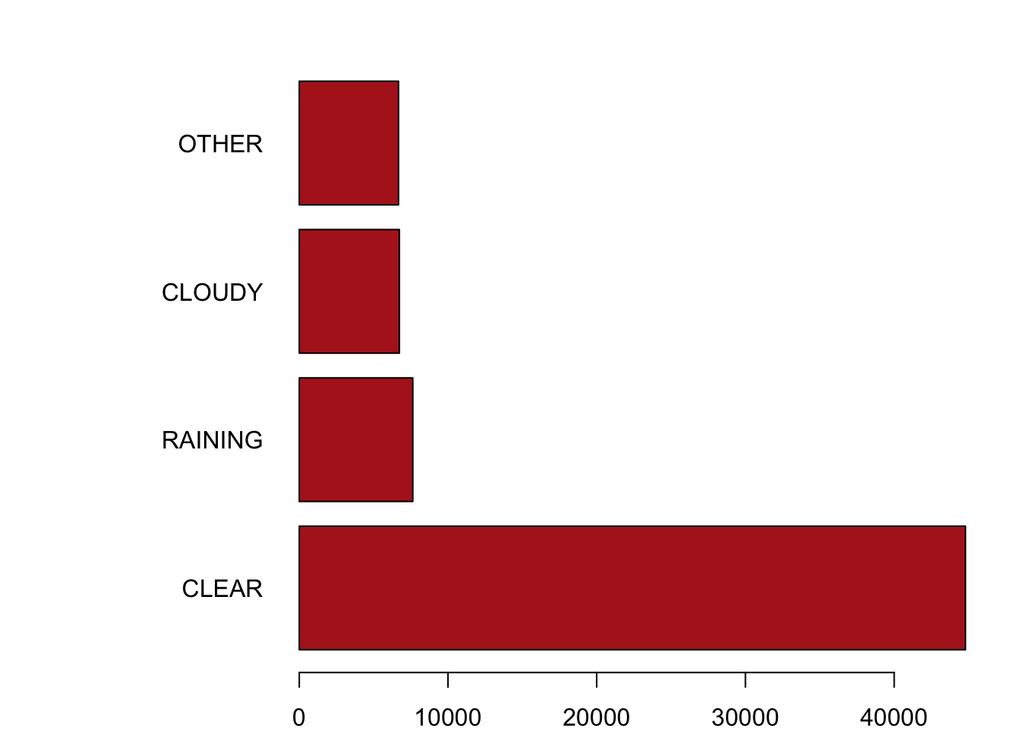

```r
# Intro: In this graph we wanted to view the number of crashes based on the weather condition when the crash happened

# Results: The weather conditions involved with the most crashed ranged from Clear, Raining, Cloudy, followed by other. The result was a bit surprising as we did not expect as many crashed when the weather condition was clear.

par(mar=c(2,10,2,2))

datWeather = dat$Weather
for(x in 1:length(datWeather)) {
  if(datWeather[x] != "CLEAR" & datWeather[x] != "RAINING" & datWeather[x] != "CLOUDY") {
    datWeather[x] = "OTHER"
  }
}

newDat = datWeather[datWeather == "RAINING" | datWeather == "CLOUDY" | datWeather == "CLEAR"  | datWeather == "OTHER"]
barplot(head(sort(table(datWeather), decreasing = T), 4), horiz=T, las=1, col="firebrick")
```

## Injury severity based on alcohol abuse

### Description:

For the graph below we wanted to obtain information about substance such as alcohol and illegal drugs being present when a driver is involved in a crash. We used two attributes (Driver.Substance.Abuse and Injury.Severity) to plot the different levels of crash injury based on substance being present.

### Results:

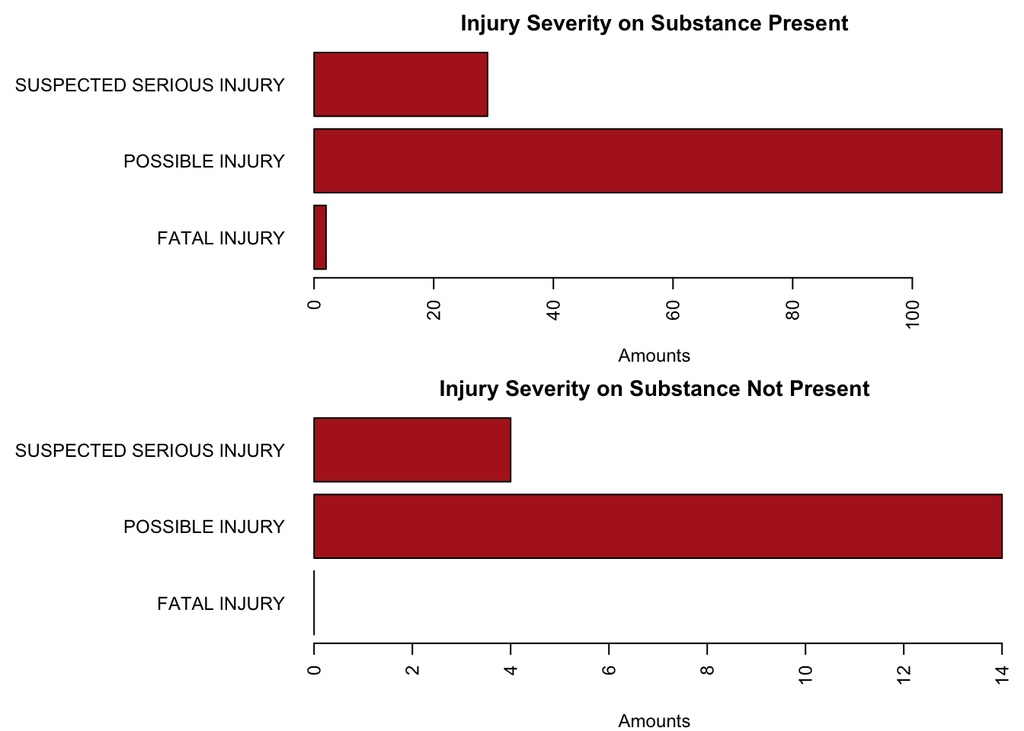

```r
# Intro: For the graph below we wanted to obtain information about substance such as alcholo and illegal drugs being present when involved in a crash. We used two attributes (Driver.Substance.Abuse and Injury.Severity) to plot the different levels of crash injury based on substance being present.

# Results: More invididuals with a substance being present were involved in more vehicle crashed than those without any thing in their their systems. In addition, fatal injuries were present when the driver was abusing a substance

par(mfrow=c(2,1), mar = c(4,14,2,1), cex = .75)
substancePresent = dat[dat$Driver.Substance.Abuse == "ALCOHOL PRESENT" | dat$Driver.Substance.Abuse == "ILLEGAL DRUG PRESENT", ]
substanceNotPresent = dat[dat$Driver.Substance.Abuse != "ALCOHOL PRESENT" & dat$Driver.Substance.Abuse == "ILLEGAL DRUG PRESENT", ]

presentAbuse = table(substancePresent$Injury.Severity)
noPresentAbuse = table(substanceNotPresent$Injury.Severity)

barplot(c(presentAbuse["FATAL INJURY"], presentAbuse["POSSIBLE INJURY"], presentAbuse["SUSPECTED SERIOUS INJURY"]), col="firebrick", main = "Injury Severity on Substance Present",
    xlab = "Amounts", horiz = T, las=2)
barplot(c(noPresentAbuse["FATAL INJURY"], noPresentAbuse["POSSIBLE INJURY"], noPresentAbuse["SUSPECTED SERIOUS INJURY"]), col="firebrick", main = "Injury Severity on Substance Not Present",
    xlab = "Amounts", horiz = T, las=2)
```

## Barplot of vehicles that have been destroyed, disabled, or still functional depending of the vehicle body type

### Description:

For the graph below we wanted to obtain the frequencies for the damage extent on vehicles based on the body type.

### Results:

The bar graph illustrates that SUVs and passenger cars involved in collisions had been mostly disabled and a few destroyed. However, pick up trucks seemed to withstand most collisions resulting in the vehicle being mostly functional.

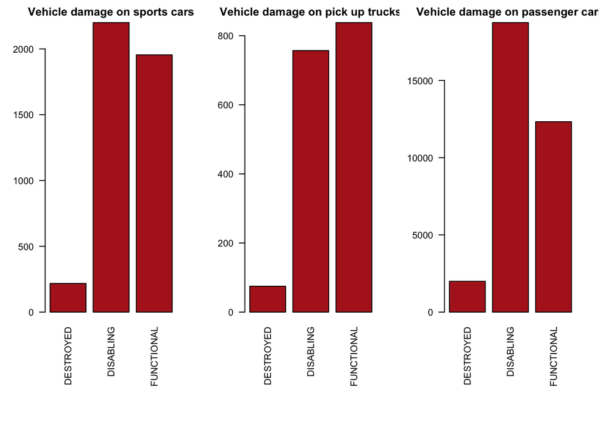

```r
par(mfrow=c(1,3))
par(mar=c(10,4,2,2))
#Intro:
#Result:
pickupTruck = table(dat$Vehicle.Damage.Extent[dat$Vehicle.Body.Type == "PICKUP TRUCK"])
sportsVehicles = table(dat$Vehicle.Damage.Extent[dat$Vehicle.Body.Type == "(SPORT) UTILITY VEHICLE"])
passengerCar = table(dat$Vehicle.Damage.Extent[dat$Vehicle.Body.Type == "PASSENGER CAR"])

barplot(c(sportsVehicles["DESTROYED"], sportsVehicles["DISABLING"], sportsVehicles["FUNCTIONAL"]), col="firebrick", main = "Vehicle damage on sports cars", las=2)
barplot(c(pickupTruck["DESTROYED"], pickupTruck["DISABLING"], pickupTruck["FUNCTIONAL"]), col="firebrick", main = "Vehicle damage on pick up trucks", las=2)
barplot(c(passengerCar["DESTROYED"], passengerCar["DISABLING"], passengerCar["FUNCTIONAL"]), col="firebrick", main = "Vehicle damage on passenger cars", las=2)
```

## Vehicle damage extend average based on the vechicle body type

### Description:

For this section we wanted to obtain the average vehicle damage extent based on the vehicle body type. The attributes that were used for this observation was (Vehicle.Body.Type and Vehicle.Damage.Extent)

### Results:

The results illustrate that pickup trucks were less prone to be destroyed or disabled compared to SUVs and passenger cars. In addition, passenger cars had the worst average performance for all three categories.

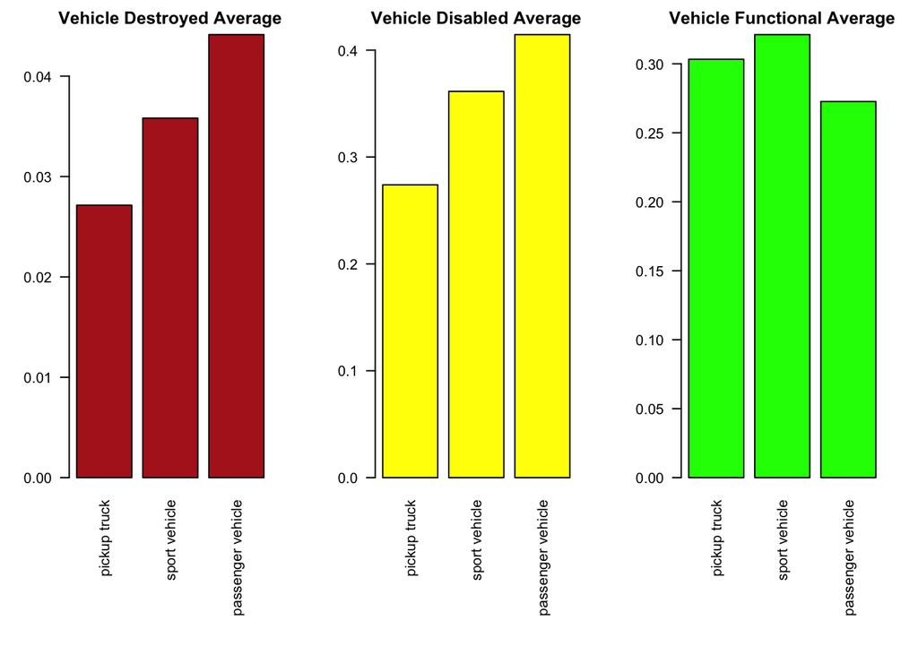

```r
par(mfrow=c(1,3), mar = c(10,4,2,2))

#Intro: For this section we wanted to obtain the average vehicle damage extent based on the vehicle body type. The attributes that were used for this observation was (Vehicle.Body.Type and Vehicle.Damage.Extent)

#Result:The results illustrate that pickup trucks were less prone to be destroyed or disabled compared to SUVs and passanger cars. In addition, passanger cars and SUVs had similar results for the vehicle damage extent

pickupTruck = dat[dat$Vehicle.Body.Type == "PICKUP TRUCK",]
pickupTruckDestroyedAvg = mean(pickupTruck$Vehicle.Damage.Extent == "DESTROYED")
pickupTruckDisablingAvg = mean(pickupTruck$Vehicle.Damage.Extent == "DISABLING")
pickupTruckFunctionalAvg = mean(pickupTruck$Vehicle.Damage.Extent == "FUNCTIONAL")

sportsVehicles = dat[dat$Vehicle.Body.Type == "(SPORT) UTILITY VEHICLE",]
sportsVehiclesDestroyedAvg = mean(sportsVehicles$Vehicle.Damage.Extent == "DESTROYED")
sportsVehiclesDisablingAvg = mean(sportsVehicles$Vehicle.Damage.Extent == "DISABLING")
sportsVehiclesFunctionalAvg = mean(sportsVehicles$Vehicle.Damage.Extent == "FUNCTIONAL")


passengerCar = dat[dat$Vehicle.Body.Type == "PASSENGER CAR",]
passengerCarDestroyedAvg = mean(passengerCar$Vehicle.Damage.Extent == "DESTROYED")
passengerCarDisablingAvg = mean(passengerCar$Vehicle.Damage.Extent == "DISABLING")
passengerCarFunctionalAvg = mean(passengerCar$Vehicle.Damage.Extent == "FUNCTIONAL")

avgDestroyed = c(pickupTruckDestroyedAvg, sportsVehiclesDestroyedAvg, passengerCarDestroyedAvg)
names(avgDestroyed) = c("pickup truck", "sport vehicle", "passenger vehicle")

avgDisabling = c(pickupTruckDisablingAvg, sportsVehiclesDisablingAvg, passengerCarDisablingAvg)
names(avgDisabling) = c("pickup truck", "sport vehicle", "passenger vehicle")

avgFunctional = c(pickupTruckFunctionalAvg, sportsVehiclesFunctionalAvg, passengerCarFunctionalAvg)
names(avgFunctional) = c("pickup truck", "sport vehicle", "passenger vehicle")


barplot(avgDestroyed, col="firebrick", main = "Vehicle Destroyed Average",
    las=2)
barplot(avgDisabling, col="yellow", main = "Vehicle Disabled Average",
    las=2)
barplot(avgFunctional, col="green", main = "Vehicle Functional Average",
    las=2)
```

## Most common vehicle collisions

### Description:

This graph illustrates the most collision with the montgomery county.

### Results:

The most common collision in the dataset were same direction rear ends, followed by straight movement angle, other, and single vehicle

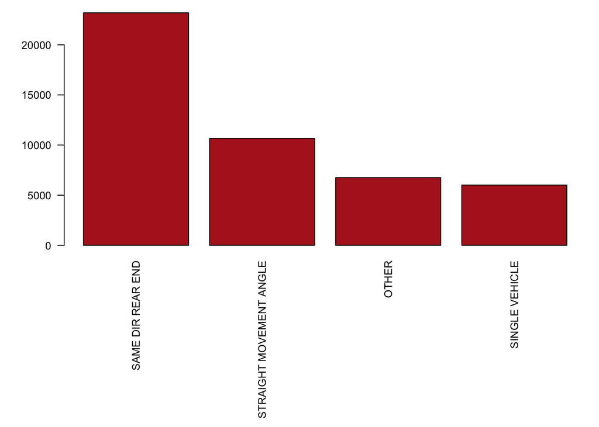

```r
#Intro:
#Result:
par(mar=c(14,5,1,1), cex = .75)
newDat = dat[dat$Collision.Type != "" && dat$Collision.Type != "UNKNOWN",]
topCollisons = head(sort(table(newDat$Collision.Type), decreasing = T), 4)
barplot(topCollisons, col = "firebrick",las=2)
```

## Most common crashed on certain roads

### Description:

The graph below answer the question of what type of crashes are common on New Hampshire and Georgia road. The New Hampshire and Georgia Road were involved with the most collision in the Montgomery County. The attributes that were graphed consisted of Road.Name and Collision.Type.

### Results:

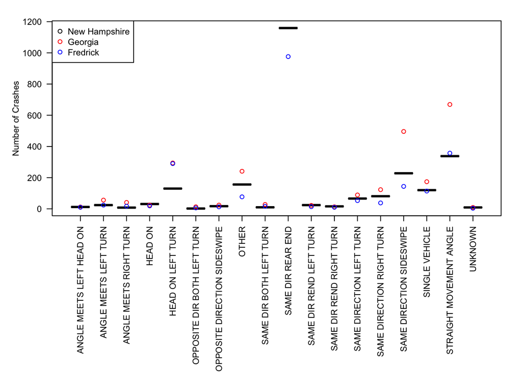

```r
#are some kinds of crashes more common on certain kinds of roads
#Road.Name, Collision.Type,
#Top three roads with number of crashes GEORGIA AVE NEW HAMPSHIRE AVE      FREDERICK RD
#Intro:
#Result:
georgiaAve = dat[dat$Road.Name == "GEORGIA AVE",]
newHampshireAve = dat[dat$Road.Name == "NEW HAMPSHIRE AVE",]
frederickRoad = dat[dat$Road.Name == "FREDERICK RD",]
#head(sort(table(georgiaAve$Collision.Type), decreasing = T), 3)
#head(sort(table(newHampshireAve$Collision.Type), decreasing = T), 3)
stash = data.frame(table(georgiaAve$Collision.Type),table(newHampshireAve$Collision.Type),table(frederickRoad$Collision.Type))[c(1,2,4,6)]
names(stash) = as.character(stash[1])
colnames(stash) = c("names","Georgia", "NewHampsire", "Fredrick")
par(mar = c(15,5,2,2), las=2, cex = 0.7)
plot(stash$NewHampsire ~ stash$names, xlab = "", ylab = "Number of Crashes", type = "p")
lines(stash$Georgia, type = "p", col = "RED")
lines(stash$Fredrick, type = "p", col = "blue")
legend( "topleft", legend = c("New Hampshire", "Georgia", "Fredrick" ), col = c("black", "red", "blue"), pch = 1)
```

## Map of the different collision within Montgomery County

### Descrition:

For this graph we wanted to illustrate a map with across the Montgomery County with dots on the location of each cross

### Results:

The graph displays roads drawed by points across the graph illustrating the common areas of crashes This collision map illistrates the approximate locations of Montgomery County roads. While the map itself is cluttered, the roads themselves can be made out.

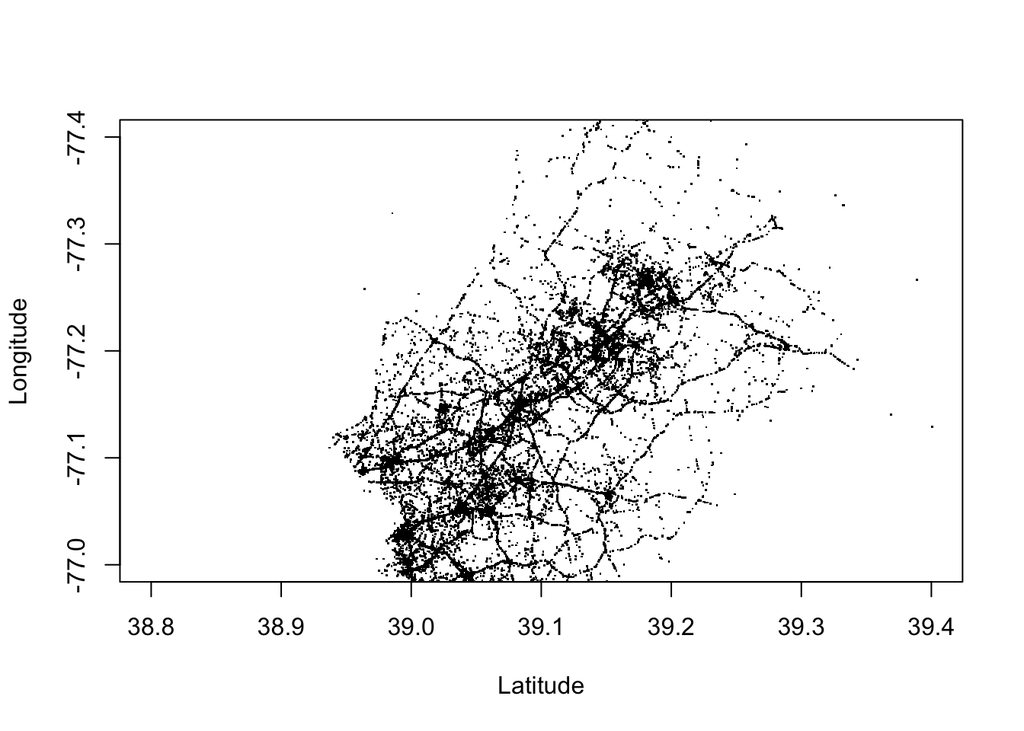

```r
#Intro: For this graph we wanted to illustrate a map with across the Montgomery County with dots on the location of each cross
#Result: The graph displays roads drawed by points across the graph illustrating the common areas of crashes
plot(dat$Latitude, dat$Longitude, xlim = c(38.8, 39.4), ylim = c(-77, -77.4), pch = ".",
     xlab = "Latitude", ylab = "Longitude")
```

## Map of off road collisions within Montgomery County

### Description:

For this graph we wanted to illustrate the collisons that have occured off the road to help us determine if these type of collision are common around this county

### Results:

The graph displays many of the off road collisions occurring around the same areas. Most of these collisions also occurred near local roads Here the places where cars were off the road are higlighted. Most crashes that did occur off the roads were still near the road. The data itself explains why this is - the collisions off the road tended to occur in parking lots. This also helps to track where the Montgomery County roads lay, as the road only follows the darker points.

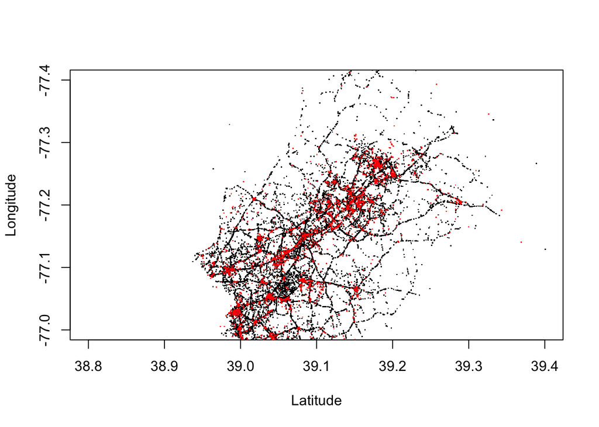

```r
#Intro: For this graph we wanted to illustrate the collisons that have occured off the road to help us determine if these type of collision are common around this county
#Result: The graph displays many of the off road collisions occuring around the same areas. Most of these collisions also occured near local roads
plot(dat$Latitude, dat$Longitude, xlim = c(38.8, 39.4), ylim = c(-77, -77.4), pch = ".", xlab = "Latitude",
     ylab="Longitude")
data=dat[dat$Off.Road.Description !="",]
points(data$Latitude, data$Longitude, col="red", pch=".",xlab = "Latitude", ylab = "Longitude")
```

## Frequency of crashes by day of the week

### Description:

For this graph we wanted a barplot to illustrate the frequency of crashes based on the day of the week.

### Results:

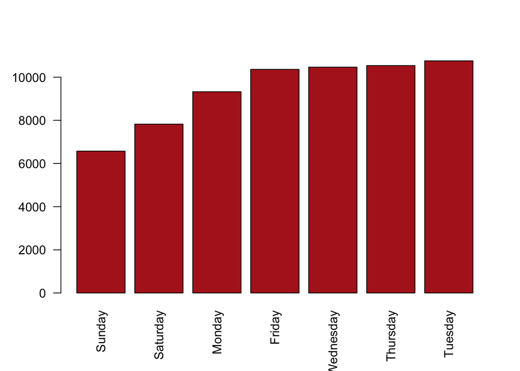

```r
#Intro:
#Result:
dat$dtime = strptime(as.character(dat$Crash.Date.Time),
                     "%m/%d/%Y %I:%M:%S %p",
                     tz="America/New_York")

day_of_the_week = table(dat$dtime$wday)
names(day_of_the_week) = c("Sunday", "Monday", "Tuesday", "Wednesday", "Thursday", "Friday", "Saturday")
barplot(sort(day_of_the_week), col = "firebrick",las=2)
```

## Time of day when crashes occur

### Description:

For the following graph we wanted to find out when most collision occur based on the time of day.

### Results:

Most collision seem to occur during morning commutes to work and after work around 3 PM - 6 PM.

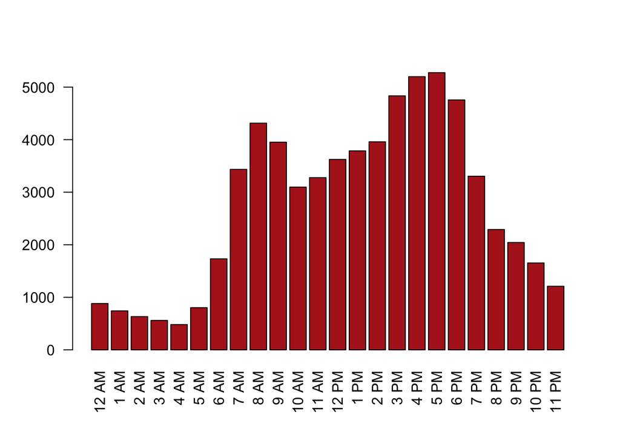

```r
#Intro:
#Result:
datTimeofDay = table(dat$dtime$hour)
names(datTimeofDay) = c("12 AM", "1 AM", "2 AM", "3 AM", "4 AM", "5 AM", "6 AM", "7 AM", "8 AM", "9 AM", "10 AM",
                        "11 AM", "12 PM", "1 PM", "2 PM", "3 PM", "4 PM", "5 PM", "6 PM", "7 PM", "8 PM", "9 PM",
                        "10 PM", "11 PM")

barplot(datTimeofDay, las=2, col = "firebrick")
```